# Reshaping

2017-04-02

# Outline

1. Exporting data from excel
2. Saving `ggplot2 plots`
3. using `tidyr`

# Exporting data from Excel

For practice, you can download the buckeye data from my website here: https://jofrhwld.github.io/data/buckeye.xls

What the menus look like will differ from one version of excel to another, and from one operating system to another, but what your goal will be is to save this excel file as a tab-delimited text file. Here’s what that looks like on Excel 2011 for Macs.

With the file open in Excel, go to File > Save as

[figure not shown]

file_menu

You can choose the file format you’re saving as from a drop down menu towards the bottom:

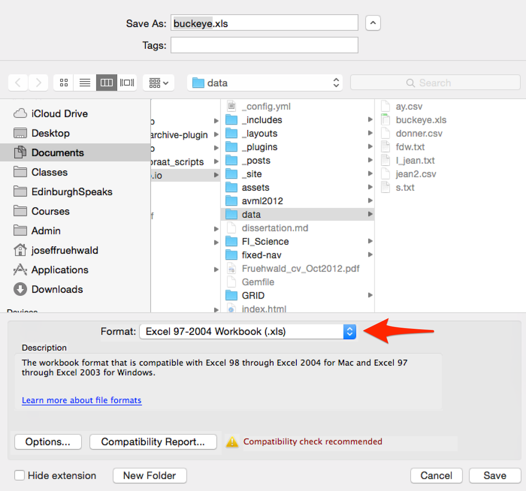

save1

From this drop down menu, you can choose either “csv” (for “comma separated values”), or the Tab Delimited File options. These are both “plain text” formats, and easily read into R using either the `read.delim()` function or the `read.csv()` function.

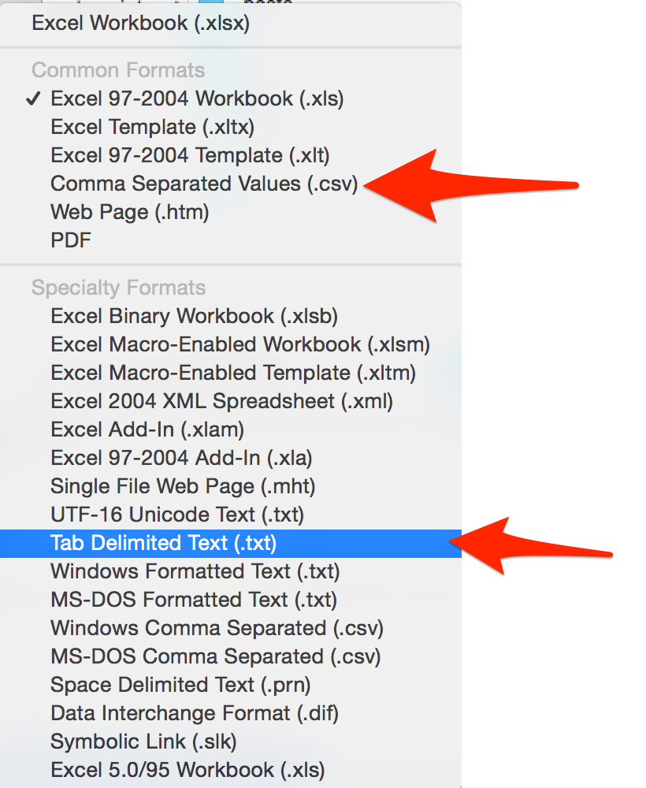

save2

For more on reading data, look back at [this section from week 2’s practical](https://jofrhwld.github.io/teaching/courses/2015_gram_var/practicals/2_r_practical.html#reading-in-data).

# Saving `ggplot2` plots

Once you’ve tweaked your `ggplot2` plots to the point that you like them, you can save them to many different file formants using `ggsave()`. Step 1, tweak your plot:

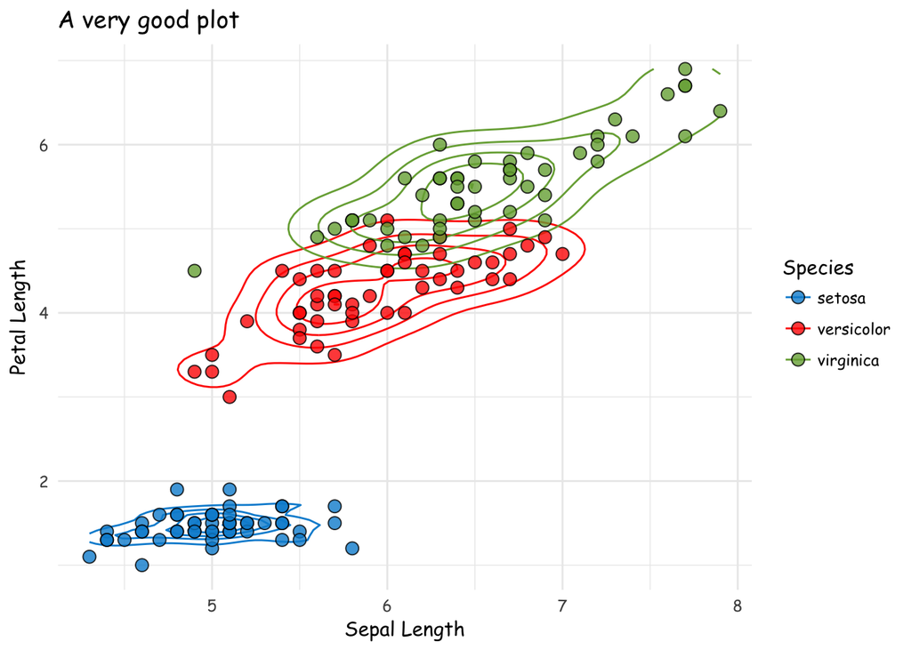

```r
library(ggplot2)
library(ggthemes)
  ggplot(iris, aes(Sepal.Length, Petal.Length, fill = Species, color = Species))+
    stat_density_2d(bins = 5)+
    geom_point(color = "black",
               shape = 21,
               size = 3,
               alpha = 0.8)+
    xlab("Sepal Length")+
    ylab("Petal Length")+
    scale_color_fivethirtyeight()+
    scale_fill_fivethirtyeight()+
    theme_minimal()+
    theme(text = element_text(family = 'Comic Sans MS'))+
    ggtitle("A very good plot")
```

Step2: Assign this plot to an object:

```r
v_good_plot <-   ggplot(iris, aes(Sepal.Length, Petal.Length, fill = Species, color = Species))+
                      stat_density_2d(bins = 5)+
                      geom_point(color = "black",
                                 shape = 21,
                                 size = 3,
                                 alpha = 0.8)+
                      xlab("Sepal Length")+
                      ylab("Petal Length")+
                      scale_color_fivethirtyeight()+
                      scale_fill_fivethirtyeight()+
                      theme_minimal()+
                      theme(text = element_text(family = 'Comic Sans MS'))+
                      ggtitle("A very good plot")
```

Step 3, `ggsave()` it.

```r
ggsave(v_good_plot, filename = "v_good_plot.png", width = 8, height = 5, units = 'in')
```

I would usually recommend saving plots to pdf, but this time our fun with fonts messed that up. By just changing the file extension, you can save ggplot plots to:

```
"eps", "ps", "tex" (pictex), "pdf", "jpeg", "tiff", "png", "bmp", "svg"
```

Usually, it’s better for plots to be wider than they are tall, and I’d recommend keeping you plots somewhere between 5 and 8 inches wide, and between 4 and 5 inches tall. But of course, all rules must be broken sometimes.

# Reshaping Data

Sometimes, you’ll want to take data from columns, and turn them into rows, or vice versa. For example, take the following data frame:

```r
bad_td <- data.frame(speaker = c("speaker1", "speaker2"),
                      past_ret = c(50,45),
                      past_del = c(10, 30),
                      mono_ret = c(100, 75),
                      mono_del = c(200, 90))
print(bad_td)
```

```
##    speaker past_ret past_del mono_ret mono_del
## 1 speaker1       50       10      100      200
## 2 speaker2       45       30       75       90
```

Here, there is one row for each speaker,

- `past_ret` = the number of past tense words each speaker produced with /t/
- `past_del` = the number of past tense words each speaker produced with $\emptyset$
- `mono_ret` = the number of monomorphemic words each speaker produced with /t/
- `mono_del` = the number of monomorphemic words each speaker produced with $\emptyset$

This isn’t a *very* useful data format. Think about how you might ggplot with it. Here’s my best attempt at an informative plot showing the rate at which each speaker pronounce their /t,d/ in past tense forms:

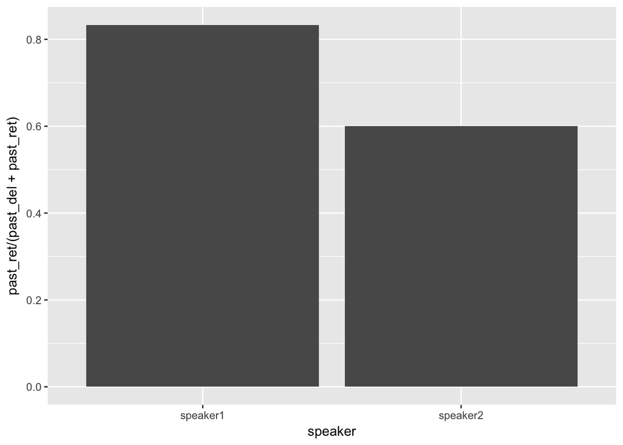

```r
  library(ggplot2)

  ggplot(bad_td, aes(speaker, past_ret/(past_del+past_ret)))+
    geom_bar(stat = "identity")
```

But in a lot of ways, we’re limited by the data format. We’re not, for example, able to easily generate a plot that shows *both* the past tense and monomorphemic data at the same time.

This isn’t just an issue about the kind of data format `ggplot` expects. The structure of the data in `bad_td` is violating principles of “tidy data”.

4. Some principles of tidy data, from [Wickham (2014)](http://vita.had.co.nz/papers/tidy-data.pdf):
1. Each variable forms a column.
2. Each observation forms a row.

The problem with `bad_td` is that the morphological class, and the kind of TD variant are both *variables*, but they’re being used as part of the column name.

## `gather()`

We can easily fix the `bad_td` data frame by using the `gather()` function from the `tidyr` package.

```r
  install.packages("tidyr")
```

The `gather()` function takes the following argumentss:

1. a data frame to be melted
2. the name you want the call the `key` column
3. the name you want to call the `valye` column
4. The columns you wish to “gather”

It makes sense when you see it in action.

```r
  library(tidyr)

  # before
  print(bad_td)
```

```
##    speaker past_ret past_del mono_ret mono_del
## 1 speaker1       50       10      100      200
## 2 speaker2       45       30       75       90
```

```r
  # you can choose columns either by their name, or numerical index
  better_td <- bad_td %>%
                    gather(gram_outcome, n, past_ret:mono_del)
  print(better_td)
```

```
##    speaker gram_outcome   n
## 1 speaker1     past_ret  50
## 2 speaker2     past_ret  45
## 3 speaker1     past_del  10
## 4 speaker2     past_del  30
## 5 speaker1     mono_ret 100
## 6 speaker2     mono_ret  75
## 7 speaker1     mono_del 200
## 8 speaker2     mono_del  90
```

## `separate()`

This particular example isn’t quite perfect yet. The morphological class and the /t,d/ variant are two different variables, but in `better_td` they’re smashed together into just one column. We can split these this one column into two with the `separate()` function, also from `tidyr`.

`separate()` takes three arguments:

1. The column that you want to split up.
2. Pattern you want to use to split the column.
3. The names of the new columns that will be created.

```r
  print(better_td)
```

```
##    speaker gram_outcome   n
## 1 speaker1     past_ret  50
## 2 speaker2     past_ret  45
## 3 speaker1     past_del  10
## 4 speaker2     past_del  30
## 5 speaker1     mono_ret 100
## 6 speaker2     mono_ret  75
## 7 speaker1     mono_del 200
## 8 speaker2     mono_del  90
```

```r
  # split variable based on the underscore, "_", symbol
  best_td <- better_td %>%
                separate(col = gram_outcome, pattern = "_", into = c("Gram", "Variant"))
  print(best_td)
```

```
##    speaker Gram Variant   n
## 1 speaker1 past     ret  50
## 2 speaker2 past     ret  45
## 3 speaker1 past     del  10
## 4 speaker2 past     del  30
## 5 speaker1 mono     ret 100
## 6 speaker2 mono     ret  75
## 7 speaker1 mono     del 200
## 8 speaker2 mono     del  90
```

Now, we can do some useful `ggplot`ing, or statistical analysis.

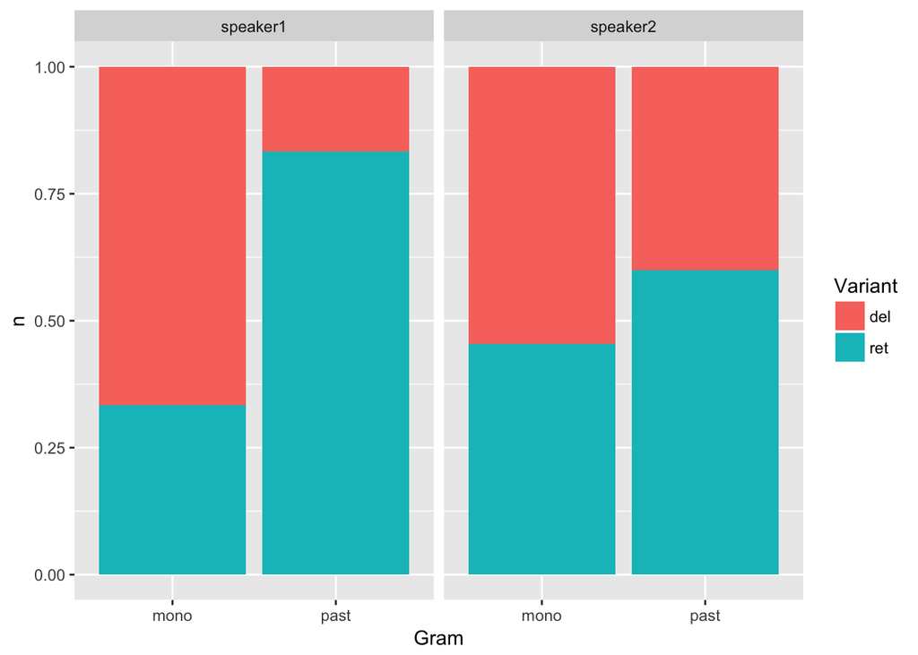

```r
  ggplot(best_td, aes(Gram, n, fill = Variant))+
      geom_bar(stat = "identity", position = "fill")+
      facet_wrap(~speaker)
```

## `spread()`

Sometimes, though, you might want to go the other way, and turn some row data into column data. You can do this using `spread()` from the `tidyr` package.

The `spread()` function takes three arguments:

1. A data frame.
2. The column you want to create new columns with.
3. The value you want to fill those new columns with.

So, let’s take our current `best_td` dataframe:

| speaker | Gram | Variant | n |
| --- | --- | --- | --- |
| speaker1 | past | ret | 50 |
| speaker2 | past | ret | 45 |
| speaker1 | past | del | 10 |
| speaker2 | past | del | 30 |
| speaker1 | mono | ret | 100 |
| speaker2 | mono | ret | 75 |
| speaker1 | mono | del | 200 |
| speaker2 | mono | del | 90 |

Let’s try to sketch out what a new table could look like with this dataframe:

[output not shown]

We can do this very easilly with spread.

This is the basic table we’re going to get out:

```r
  different_td <- best_td%>%
                    spread(Variant, n)
```

Just to remind you of what we started with and what we have now:

```r
kable(bad_td)
```

| speaker | past_ret | past_del | mono_ret | mono_del |
| --- | --- | --- | --- | --- |
| speaker1 | 50 | 10 | 100 | 200 |
| speaker2 | 45 | 30 | 75 | 90 |

```r
kable(different_td)
```

| speaker | Gram | del | ret |
| --- | --- | --- | --- |
| speaker1 | mono | 200 | 100 |
| speaker1 | past | 10 | 50 |
| speaker2 | mono | 90 | 75 |
| speaker2 | past | 30 | 45 |

And we can chain this sequence of bad to useful with the dplyr `%>%`

```r
bad_td %>%
  gather(gram_outcome, n, past_ret:mono_del)%>%
  separate(gram_outcome, sep = "_", into = c("Gram", "Variant"))%>%
  spread(Variant, n)
```

```
##    speaker Gram del ret
## 1 speaker1 mono 200 100
## 2 speaker1 past  10  50
## 3 speaker2 mono  90  75
## 4 speaker2 past  30  45
```

# A Practical Example

The exercises from this week asked you to:

5. 1. Estimate the rate of Phrase Level Retention and Word Level Retention for each individual speaker in the Buckeye data.
   2. Evaluate how well those estimates compare to the prediction that phrase leve > word level.

## Step 1: Estimate retention for each speaker for each grammatical class

```r
  library(languageVariationAndChangeData)
  library(dplyr)
  buck_to_use <- buckeye %>%
                  filter(Gram2 %in% c("mono","past")) %>%
                  select(Speaker, Gram2, td)


  retention_rates <- buck_to_use %>%
                        group_by(Speaker, Gram2) %>%
                        summarise(retention = mean(td))

  retention_rates %>% head() %>% print()
```

```
## Source: local data frame [6 x 3]
## Groups: Speaker [3]
##
##   Speaker  Gram2 retention
##    <fctr> <fctr>     <dbl>
## 1     s01   mono 0.5806452
## 2     s01   past 0.7966102
## 3     s02   mono 0.5309735
## 4     s02   past 0.6041667
## 5     s03   mono 0.5148936
## 6     s03   past 0.6000000
```

## Step 2: Divide mono/past for every speaker.

If we’re assuming the following:

|  | Word Level | Phrase Level |
| --- | --- | --- |
| mono | x | x |
| past | - | x |

Then in order to estimate the word level rate of TD Retention, we need to divide the monomorphemic retention rate by the past tense word rate

6. $\text{word} = \frac{word\times phrase}{phrase} = \frac{mono}{past}$

One easy way to do this with the retention rates we’ve just calculated is to spread the grammatical class across the columns, filling the new cells with the retention rates we’ve just estimated.

```r
  retention_wide <- retention_rates %>%
                        spread(Gram2, retention)
  retention_wide %>% head %>% print
```

```
## Source: local data frame [6 x 3]
## Groups: Speaker [6]
##
##   Speaker      mono      past
##    <fctr>     <dbl>     <dbl>
## 1     s01 0.5806452 0.7966102
## 2     s02 0.5309735 0.6041667
## 3     s03 0.5148936 0.6000000
## 4     s04 0.3294574 0.7333333
## 5     s05 0.6904762 0.8222222
## 6     s06 0.8099174 0.7619048
```

Now, it’s easy to divide `mono` by `past` for every speaker.

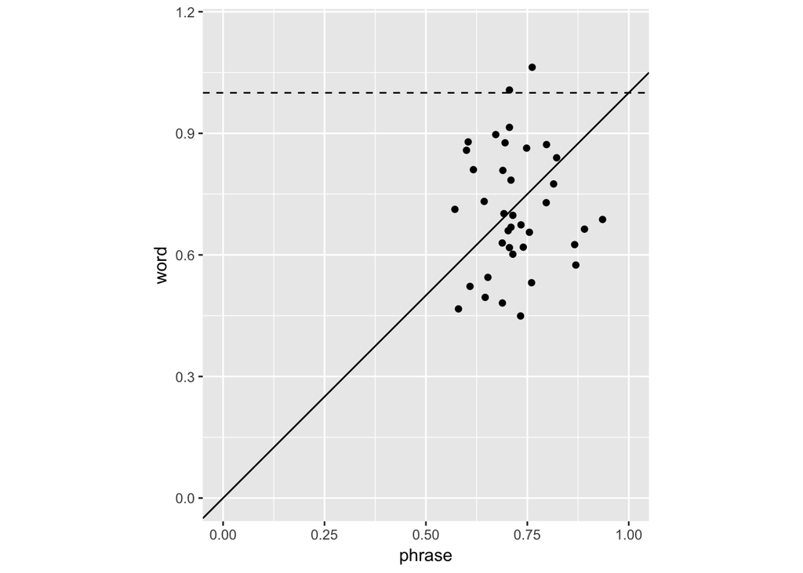

```r
level_estimates <- retention_wide %>%
                      mutate(phrase = past,
                             word = mono/past)

level_estimates %>%
  ggplot(aes(phrase, word))+
    geom_point()+
    geom_abline()+
    geom_hline(yintercept = 1, linetype = 2)+
    xlim(0,1)+
    ylim(0,1.15)+
    coord_fixed()
```

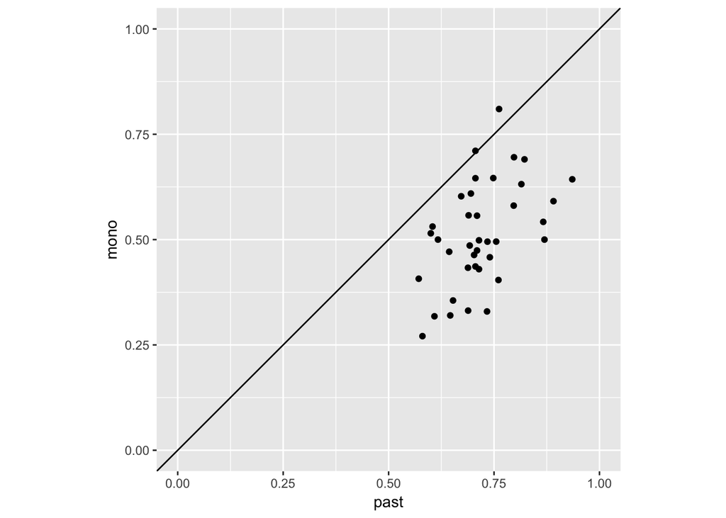

```r
level_estimates %>%
  ggplot(aes(past, mono))+
    geom_point()+
    geom_abline()+
    ylim(0,1)+
    xlim(0,1)+
    coord_fixed()
```

~